# Nutrient analysis plots and models

#### repeating for the other nutrients

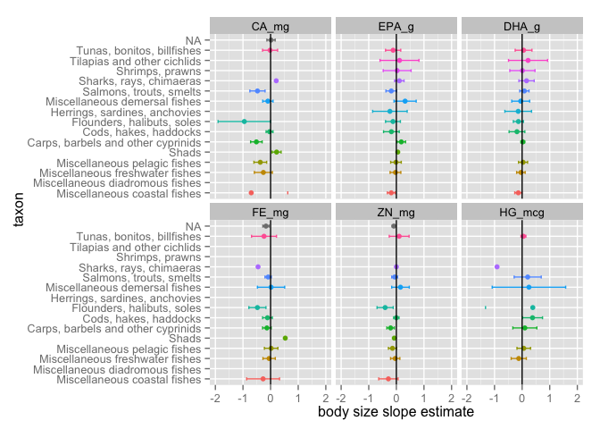

```r
# nuts <- ntbl %>% names %>% .[5:8]
#
# indep_var <- lapply(nuts, function(nutname) paste0("log(", nutname, ")"))
#
# names(indep_var) <- nuts
#
# responses <- indep_var


# for (k in nuts[[1]]){
#   responses[[k]] <- ntbl %>%
#     group_by(taxon) %>%
#     do(tidy(lm_gen(.,
#                    y = indep_var[[k]],
#                    x = "log(max_size)"),
#             conf.int = TRUE))
# }


ntbl %>%
  gather("nutrient", "value", CA_mg:HG_mcg) %>%
  group_by(taxon, nutrient) %>%
  mutate(logmass = log(max_size),
         lognutr = log(value)) %>%
  filter(!is.na(value)) %>%
  filter(!is.na(logmass)) %>%
  do(tidy(lm(lognutr ~ logmass, data = .),
          conf.int = TRUE)
     ) %>%
  filter(term == "logmass") %>%
  ggplot(aes(estimate, taxon, color = taxon)) +
    geom_point() +
    geom_errorbarh(aes(xmin = conf.low, xmax = conf.high, height = .3)) +
    geom_vline() + theme(legend.position="none") + xlab("body size slope estimate") +
  facet_wrap(~nutrient) + scale_x_continuous(limits=c(-2, 2))
```

```r
ggsave("slope_estimates.png")
```

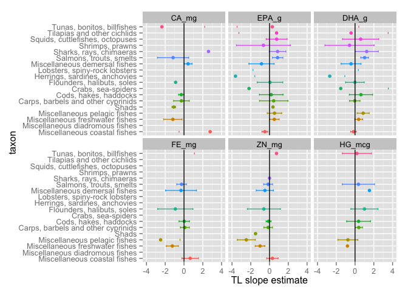

```r
#' now for trophic level subset(dftm, C!="Foo")
ntbl %>%
  filter(taxon!= "Miscellaneous diadromous fishes") %>%
  gather("nutrient", "value", CA_mg:HG_mcg) %>%
  group_by(taxon, nutrient) %>%
  mutate(lognutr = log(value)) %>%
  filter(!is.na(value)) %>%
  filter(!is.na(TL)) %>%
  do(tidy(lm(lognutr ~ TL, data = .),
          conf.int = TRUE)
     ) %>%
  filter(term == "TL") %>%
  ggplot(aes(estimate, taxon, color = taxon)) +
    geom_point() +
    geom_errorbarh(aes(xmin = conf.low, xmax = conf.high, height = .3)) +
    geom_vline() + theme(legend.position="none") + xlab("TL slope estimate") +
  facet_wrap(~nutrient) + scale_x_continuous(limits=c(-4, 4))
```

```r
ggsave("slope_estimates.png")
```

Mercury

```r
ntbl.HG <- ntbl %>%
  filter(!is.na(HG_mcg)) %>%
  filter(!is.na(taxon)) %>%
  filter(!is.na(TL))

size.HG <- tidy(lm(log(HG_mcg) ~ TL, data = ntbl.HG), conf.int = TRUE)

summary(size.HG)
```

```
##      term              estimate        std.error        statistic
##  Length:2           Min.   :0.2455   Min.   :0.1056   Min.   :2.326
##  Class :character   1st Qu.:0.8587   1st Qu.:0.1776   1st Qu.:3.457
##  Mode  :character   Median :1.4718   Median :0.2497   Median :4.588
##                     Mean   :1.4718   Mean   :0.2497   Mean   :4.588
##                     3rd Qu.:2.0849   3rd Qu.:0.3218   3rd Qu.:5.720
##                     Max.   :2.6980   Max.   :0.3938   Max.   :6.851
##     p.value             conf.low         conf.high
##  Min.   :1.000e-09   Min.   :0.03589   Min.   :0.4552
##  1st Qu.:5.553e-03   1st Qu.:0.50588   1st Qu.:1.2114
##  Median :1.111e-02   Median :0.97586   Median :1.9677
##  Mean   :1.111e-02   Mean   :0.97586   Mean   :1.9677
##  3rd Qu.:1.666e-02   3rd Qu.:1.44585   3rd Qu.:2.7239
##  Max.   :2.221e-02   Max.   :1.91583   Max.   :3.4802
```

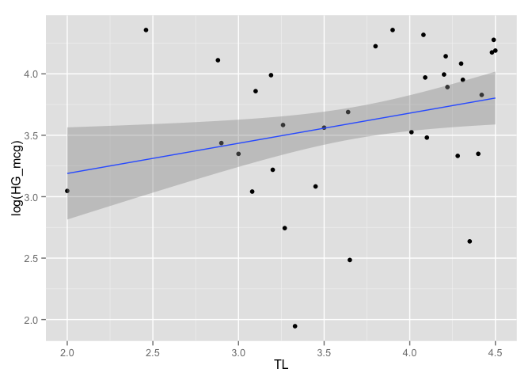

```r
ggplot(ntbl.HG, aes(TL, log(HG_mcg))) + stat_summary(fun.y= "mean", geom = "point") + stat_smooth(method = "lm")
```

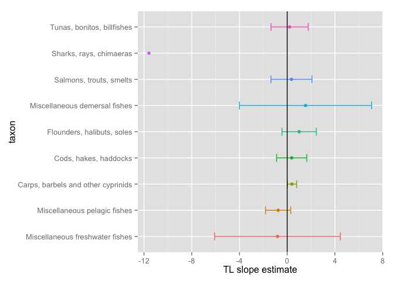

```r
TL.fitsHG <- ntbl.HG %>% group_by(taxon) %>% do(tidy(lm_general(., log(HG_mcg), TL), conf.int = TRUE))



#' And here I plot the slope estimates for each taxon.
ggplot(subset(TL.fitsHG, term == "TL"), aes(estimate, taxon, color = taxon)) +
    geom_point() +
    geom_errorbarh(aes(xmin = conf.low, xmax = conf.high, height = .3)) +
    geom_vline() + theme(legend.position="none") + xlab("TL slope estimate")
```

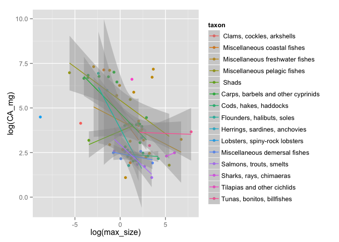

```r
ntbl.CA %>% ggplot(aes(x = log(max_size), y = log(CA_mg), color=taxon)) + stat_summary(fun.y= "mean", geom = "point") + geom_smooth(method = 'lm')
```

Residuals, grouped by taxon.

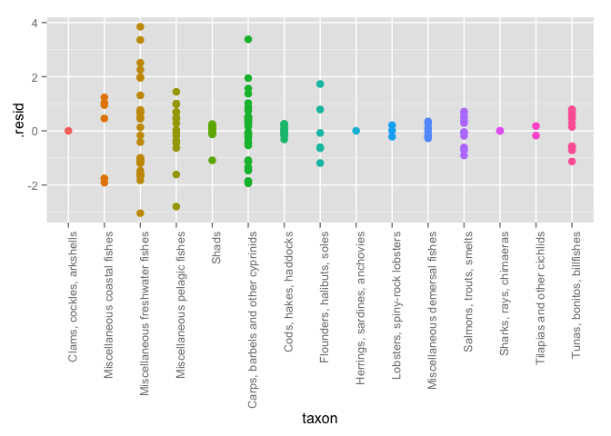

```r
ntbl.CA %>%
  group_by(taxon) %>%
  do(augment(lm(log(CA_mg) ~ log(max_size), data = .),
          conf.int = TRUE)) %>%
ggplot(., aes(x= taxon, y=.resid, color = taxon)) + geom_point(size = 3) + theme(axis.text.x = element_text(angle = 90, hjust = 1)) + theme(legend.position="none")
```

And now, plot the residuals, by size. Well at least this doesn’t look too funnel-shaped or anything too weird. That’s somewhat reassuring!

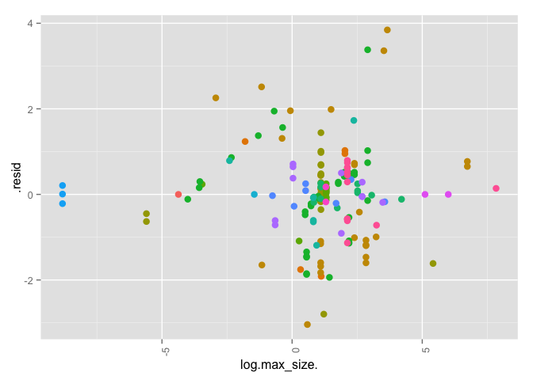

```r
ntbl.CA %>%
  group_by(taxon) %>%
  do(augment(lm(log(CA_mg) ~ log(max_size), data = .),
          conf.int = TRUE)) %>%
ggplot(., aes(x= log.max_size., y=.resid, color = taxon)) + geom_point(size = 3) + theme(axis.text.x = element_text(angle = 90, hjust = 1)) + theme(legend.position="none")
```

Here’s a function for finding the max residuals. This function allows us to figure out which taxon has the highest residual values…an indication of worst fit. Again, here we see that the group ‘Miscellaneous freshwater fishes’ has the highest residuals, i.e. worst fit to the linear model, which does make sense since it’s the most ‘grab bag’ of the groups, being ‘miscellaneous’ and all.

```r
mean_resid <- function(df) {
    size.fit <- lm(log(CA_mg) ~ log(max_size), df)
    x <- mean(abs(resid(size.fit)))
    y <- setNames(data.frame(t(x)), c("mean_residual"))
    y
}

mean_resid(ntbl.CA %>% filter(Habitat == "marine"))
```

```
##   mean_residual
## 1       1.12163
```

```r
resid_1 <- ntbl.CA %>%
group_by(taxon) %>%
do(mean_resid(.)) %>%
  unnest(mean_residual) %>%
  arrange(desc(mean_residual))
(resid_1)
```

```
## Source: local data frame [15 x 2]
##
##                                 taxon mean_residual
##                                (fctr)         (dbl)
## 1     Miscellaneous freshwater fishes     1.4097088
## 2        Miscellaneous coastal fishes     1.2239459
## 3  Carps, barbels and other cyprinids     0.8418547
## 4          Flounders, halibuts, soles     0.8390861
## 5        Miscellaneous pelagic fishes     0.7570829
## 6          Tunas, bonitos, billfishes     0.5991824
## 7             Salmons, trouts, smelts     0.4584627
## 8       Miscellaneous demersal fishes     0.1958452
## 9                               Shads     0.1942327
## 10        Tilapias and other cichlids     0.1755142
## 11              Cods, hakes, haddocks     0.1451338
## 12      Lobsters, spiny-rock lobsters     0.1437684
## 13          Clams, cockles, arkshells     0.0000000
## 14      Herrings, sardines, anchovies     0.0000000
## 15            Sharks, rays, chimaeras     0.0000000
```

Now let’s run the same models, but group by habitat. Tidy as before. Weird! Both the marine and freshwater groups show significant negative slopes and the brackish group shows a positive relationship between calcium content and body size. I can think of no biological explanation for this!

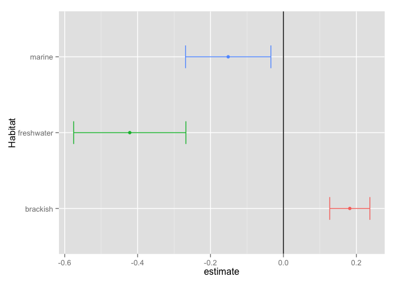

```r
  tidy.fit.hab <- ntbl.CA %>%
  group_by(Habitat) %>%
  do(tidy(lm(log(CA_mg) ~ log(max_size), data = .),
          conf.int = TRUE))


  ggplot(subset(tidy.fit.hab, term == "log(max_size)"), aes(estimate, Habitat, color = Habitat)) +
    geom_point() +
    geom_errorbarh(aes(xmin = conf.low, xmax = conf.high, height = .3)) +
    geom_vline() + theme(legend.position="none")
```

##### Putting nutrient variability in the context of human nutrition

Now, let’s explore some of the variability in nutrient content that we saw above, but this time in the context of how this matters to humans: recommended daily intake (RDI) values. Recommended daily intake values may be familiar to you in the context of those numbers printed on food products’ nutrition labels (i.e. one serving of milk gives you 30% of your RDI of calcium). These target intake values are typically set by a country’s government nutritionists.

Let’s find the % of each taxon that, in one portion, has EPA (an omega-3 fatty acid) values above RDI.

So, for one taxon, what would this look like?

```r
#' Let's try for one taxon
EPA.RDI <- ntbl.EPA %>%
  filter(taxon == "Salmons, trouts, smelts") %>%
  mutate(RDI = ifelse(EPA_g > 0.25, 1, 0)) %>%
  group_by(species) %>%
 mutate(per.RDI = sum(RDI)/n_distinct(EPA_g)) %>%
  mutate(mean.per.RDI= mean(per.RDI))
```

Here’s a function for calculating the percentage of species in a taxon that reach 25% of RDI in a single portion (i.e. 100g of fish tissue).

```r
epa.prop <- function(df) {
  (EPA.RDI <- df %>%
  mutate(RDI = ifelse(EPA_g > 0.25, 1, 0)) %>%
  group_by(species) %>%
 mutate(per.RDI = sum(RDI)/n_distinct(EPA_g)) %>%
  mutate(mean.per.RDI= mean(per.RDI)))
}
```

Here it is applied to my dataset, grouped by taxon, and unnested, summarised etc. The final output that I want is the percentage of fish species in each taxon that reaches a threshold of 25% of RDI in one portion.

#### EPA

```r
epa.prp <- ntbl.EPA %>%
  do(EPA.prp=epa.prop(.)) %>%
    unnest(EPA.prp) %>%
  group_by(taxon) %>%
  summarise(meanRDI = mean(mean.per.RDI)) %>%
  mutate(mean.percent.RDI = meanRDI * 100) %>%
  arrange(mean.percent.RDI)
```

And this graph shows these percentages ordered by increasing percentage. Yahoo! Success!

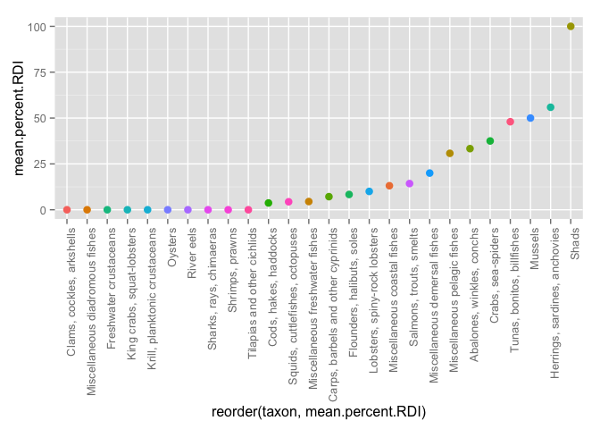

```r
ggplot(epa.prp, aes(x = reorder(taxon, mean.percent.RDI), y = mean.percent.RDI, color = taxon)) + geom_point(size = 3) + theme(axis.text.x = element_text(angle = 90, hjust = 1)) + theme(legend.position="none")
```

```r
head(epa.prp)
```

```
## Source: local data frame [6 x 3]
##
##                              taxon meanRDI mean.percent.RDI
##                             (fctr)   (dbl)            (dbl)
## 1        Clams, cockles, arkshells       0                0
## 2  Miscellaneous diadromous fishes       0                0
## 3           Freshwater crustaceans       0                0
## 4       King crabs, squat-lobsters       0                0
## 5    Krill, planktonic crustaceans       0                0
## 6                          Oysters       0                0
```

#### DHA

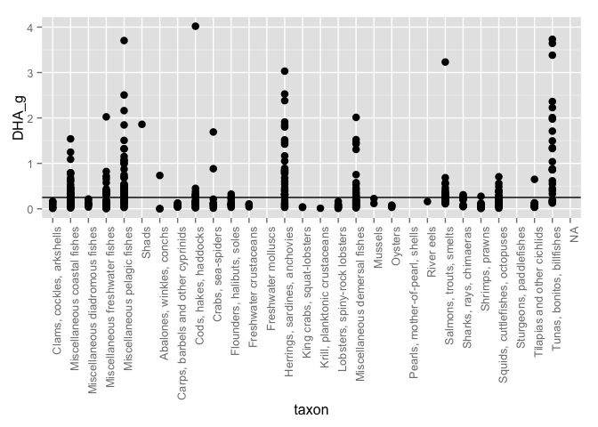

```r
ntbl.DHA <- ntbl %>%
  filter(!is.na(Abs_lat)) %>%
  filter(!is.na(DHA_g)) %>%
  filter(!is.na(taxon))

ggplot(ntbl, aes(x=taxon, y=DHA_g)) + geom_point(size = 3) + theme(axis.text.x = element_text(angle = 90, hjust = 1)) +geom_hline(aes(yintercept=0.25))
```

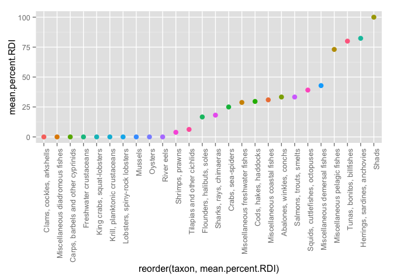

```r
dha.prop <- function(df) {
  (DHA.RDI <- df %>%
  mutate(RDI = ifelse(DHA_g > 0.25, 1, 0)) %>%
  group_by(species) %>%
 mutate(per.RDI = sum(RDI)/n_distinct(DHA_g)) %>%
  mutate(mean.per.RDI= mean(per.RDI)))
}

dha.prp <- ntbl.DHA%>%
  do(DHA.prp=dha.prop(.)) %>%
    unnest(DHA.prp) %>%
  group_by(taxon) %>%
  summarise(meanRDI = mean(mean.per.RDI)) %>%
  mutate(mean.percent.RDI = meanRDI * 100) %>%
  arrange(mean.percent.RDI)

ggplot(dha.prp, aes(x = reorder(taxon, mean.percent.RDI), y = mean.percent.RDI, color = taxon)) + geom_point(size = 3) + theme(axis.text.x = element_text(angle = 90, hjust = 1)) + theme(legend.position="none")
```

#### Calcium

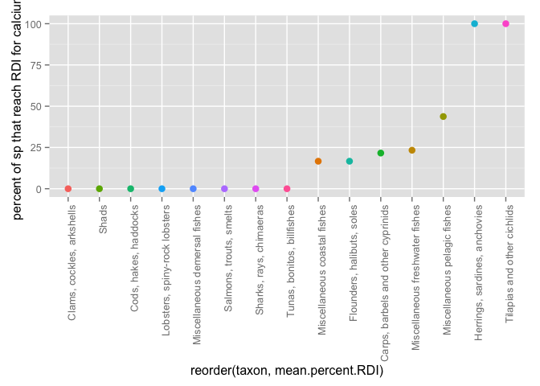

```r
CA.prop <- function(df) {
  (CA.RDI <- df %>%
  mutate(RDI = ifelse(CA_mg > 250, 1, 0)) %>%
  group_by(species) %>%
 mutate(per.RDI = sum(RDI)/n_distinct(CA_mg)) %>%
  mutate(mean.per.RDI= mean(per.RDI)))
}

CA.prp <- ntbl.CA%>%
  do(CA.prp=CA.prop(.)) %>%
    unnest(CA.prp) %>%
  group_by(taxon) %>%
  summarise(meanRDI = mean(mean.per.RDI)) %>%
  mutate(mean.percent.RDI = meanRDI * 100) %>%
  arrange(mean.percent.RDI)

ggplot(CA.prp, aes(x = reorder(taxon, mean.percent.RDI), y = mean.percent.RDI, color = taxon)) + geom_point(size = 3) + theme(axis.text.x = element_text(angle = 90, hjust = 1)) + theme(legend.position="none") + ylab("percent of sp that reach RDI for calcium")
```

#### Zinc

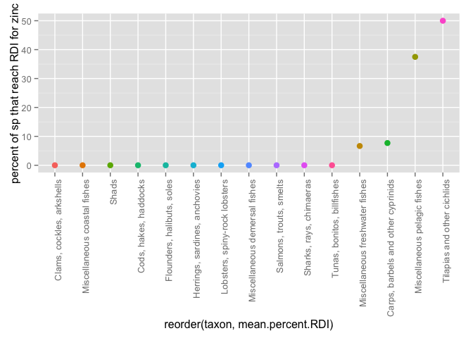

```r
ntbl.ZN <- ntbl %>%
  filter(!is.na(max_size)) %>%
  filter(!is.na(ZN_mg)) %>%
  filter(!is.na(taxon))


ZN.prop <- function(df) {
  (ZN.RDI <- df %>%
  mutate(RDI = ifelse(ZN_mg > (11/4), 1, 0)) %>%
  group_by(species) %>%
 mutate(per.RDI = sum(RDI)/n_distinct(ZN_mg)) %>%
  mutate(mean.per.RDI= mean(per.RDI)))
}

ZN.prp <- ntbl.ZN%>%
  do(ZN.prp=ZN.prop(.)) %>%
    unnest(ZN.prp) %>%
  group_by(taxon) %>%
  summarise(meanRDI = mean(mean.per.RDI)) %>%
  mutate(mean.percent.RDI = meanRDI * 100) %>%
  arrange(mean.percent.RDI)

ggplot(ZN.prp, aes(x = reorder(taxon, mean.percent.RDI), y = mean.percent.RDI, color = taxon)) + geom_point(size = 3) + theme(axis.text.x = element_text(angle = 90, hjust = 1)) + theme(legend.position="none") + ylab("percent of sp that reach RDI for zinc")
```

#### Iron

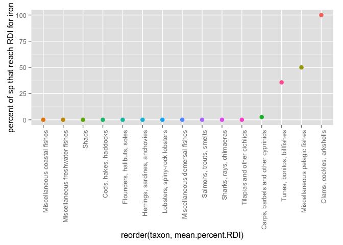

```r
ntbl.FE <- ntbl %>%
  filter(!is.na(max_size)) %>%
  filter(!is.na(FE_mg)) %>%
  filter(!is.na(taxon))


FE.prop <- function(df) {
  (FE.RDI <- df %>%
  mutate(RDI = ifelse(FE_mg > (18/4), 1, 0)) %>%
  group_by(species) %>%
 mutate(per.RDI = sum(RDI)/n_distinct(FE_mg)) %>%
  mutate(mean.per.RDI= mean(per.RDI)))
}

FE.prp <- ntbl.FE%>%
  do(FE.prp=FE.prop(.)) %>%
    unnest(FE.prp) %>%
  group_by(taxon) %>%
  summarise(meanRDI = mean(mean.per.RDI)) %>%
  mutate(mean.percent.RDI = meanRDI * 100) %>%
  arrange(mean.percent.RDI)

ggplot(FE.prp, aes(x = reorder(taxon, mean.percent.RDI), y = mean.percent.RDI, color = taxon)) + geom_point(size = 3) + theme(axis.text.x = element_text(angle = 90, hjust = 1)) + theme(legend.position="none") + ylab("percent of sp that reach RDI for iron")
```

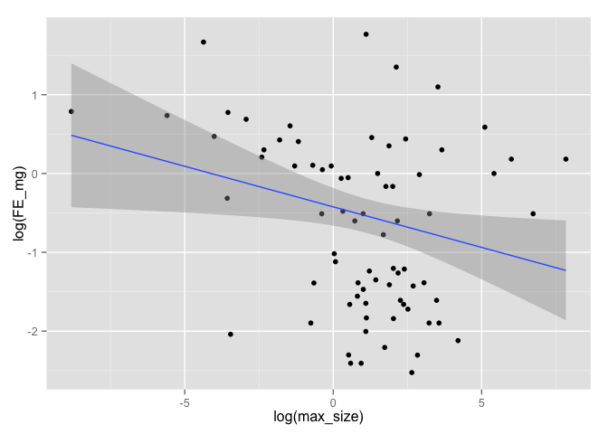

```r
ntbl %>%
  filter(!is.na(Abs_lat)) %>%
  filter(!is.na(FE_mg)) %>%
  filter(!is.na(taxon)) %>%
  filter(!is.na(TL)) %>%
  filter(!is.na(Habitat)) %>%
  filter(!is.na(max_size)) %>%
  ggplot(., aes(x=log(max_size), y=log(FE_mg))) + stat_summary(fun.y= "mean", geom = "point") + geom_smooth(method = 'lm')
```

```r
ntbl.FE <- ntbl %>%
  filter(!is.na(Abs_lat)) %>%
  filter(!is.na(FE_mg)) %>%
  filter(!is.na(taxon)) %>%
  filter(!is.na(TL)) %>%
  filter(!is.na(Habitat)) %>%
  filter(!is.na(max_size))

FE.1 <- lm(log(FE_mg) ~ log(max_size)*TL + log(max_size)*Abs_lat + log(max_size)*Habitat, data=ntbl.FE, na.action = "na.fail")

dredge(FE.1) #' best model has lat, habitat, size, and lat*size
```

```
## Fixed term is "(Intercept)"
```

```
## Global model call: lm(formula = log(FE_mg) ~ log(max_size) * TL + log(max_size) *
##     Abs_lat + log(max_size) * Habitat, data = ntbl.FE, na.action = "na.fail")
## ---
## Model selection table
##        (Int)  Abs_lat Hbt log(max_siz)        TL Abs_lat:log(max_siz)
## 24  -0.49750 -0.04667   +      0.18020                      -0.006051
## 32  -0.59970 -0.04680   +      0.18040  0.031980            -0.006145
## 56  -0.49420 -0.04641   +      0.18860                      -0.006184
## 96  -0.30370 -0.04670   +     -0.12820 -0.101000            -0.005424
## 64  -0.59960 -0.04651   +      0.19000  0.033100            -0.006301
## 4   -0.26750 -0.04965   +
## 128 -0.29430 -0.04590   +     -0.11150 -0.102000            -0.005824
## 8   -0.49810 -0.04770   +     -0.04661
## 40  -0.53680 -0.05054   +     -0.08711
## 80   0.04201 -0.04721   +     -0.43630 -0.225300
```

[output cut: 62 more lines]

```r
FE.R1 <- lm(log(FE_mg) ~ log(max_size)*Abs_lat + Habitat, data=ntbl.FE, na.action = "na.fail")
summary(FE.R1)
```

```
##
## Call:
## lm(formula = log(FE_mg) ~ log(max_size) * Abs_lat + Habitat,
##     data = ntbl.FE, na.action = "na.fail")
##
## Residuals:
##      Min       1Q   Median       3Q      Max
## -2.52837 -0.72689 -0.01739  0.55986  2.83144
##
## Coefficients:
##                        Estimate Std. Error t value Pr(>|t|)
## (Intercept)           -0.497480   1.131191  -0.440  0.66074
## log(max_size)          0.180234   0.092334   1.952  0.05284 .
## Abs_lat               -0.046673   0.006348  -7.352 1.26e-11 ***
## Habitatfreshwater      1.571346   1.113675   1.411  0.16037
## Habitatmarine          2.544786   1.115191   2.282  0.02393 *
## log(max_size):Abs_lat -0.006051   0.002243  -2.697  0.00781 **
## ---
## Signif. codes:  0 '***' 0.001 '**' 0.01 '*' 0.05 '.' 0.1 ' ' 1
##
## Residual standard error: 1.094 on 147 degrees of freedom
## Multiple R-squared:  0.3846, Adjusted R-squared:  0.3637
## F-statistic: 18.38 on 5 and 147 DF,  p-value: 3.796e-14
```

Now, let’s look at some latitudinal patterns in EPA. Because EPA is required by aquatic species to maintain membrane fluidity at cold water temperatures, I hypothesize that EPA content would be higher in cold water fish species. Here I’m using latitude from the which the fish was caught as a proxy for cold water adaptations. OK, let’s look at latitude patterns.

This figure shows how EPA content varies as a function of latitude.

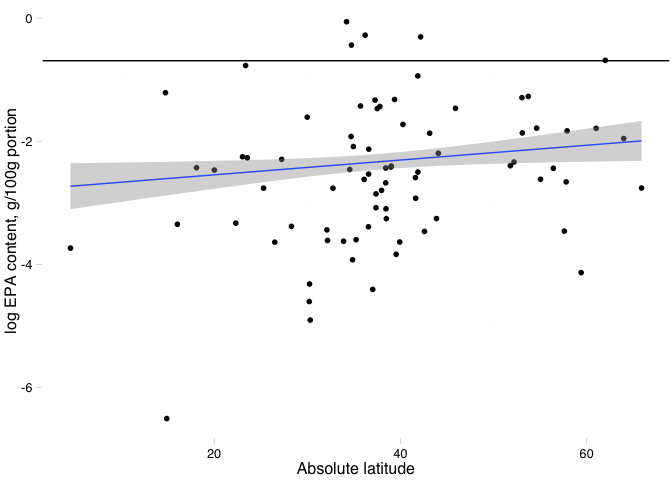

```r
p <- ggplot(subset(ntbl.EPA, Habitat == "marine"), aes(x=Abs_lat, y=log(EPA_g)))
p + stat_summary(aes(y = log(EPA_g)), fun.y=mean, geom = "point") + geom_hline(aes(yintercept=log(0.5))) + stat_smooth(method = "lm") + theme_pander() + xlab("Absolute latitude") + ylab("log EPA content, g/100g portion") + theme(legend.position="none")
```

Here I apply my EPA RDI function to the whole dataset and arrange the results by decreasing latitude.

```r
epa.prp2 <- ntbl.EPA %>%
  do(EPA.prp=epa.prop(.)) %>%
    unnest(EPA.prp) %>%
arrange(desc(Abs_lat))
```

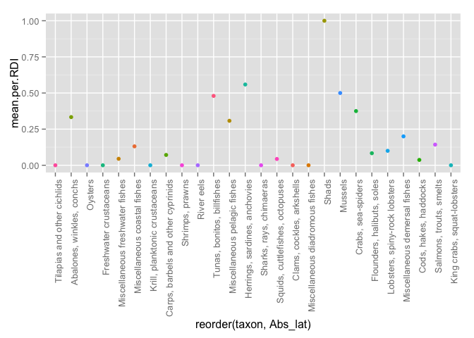

```r
ggplot(epa.prp2, aes(x = reorder(taxon, Abs_lat), y = mean.per.RDI, color = taxon)) + stat_summary(fun.y= "mean", geom = "point") + theme(axis.text.x = element_text(angle = 90, hjust = 1)) + theme(legend.position="none")
```

Here I tried to apply this function to all taxa individually, but couldn’t figure out. See below for where I was getting errors.

```r
#' this doesn't work, because I can't figure out how to pull out the right column to unnest.
#' epa.prop2 <- function(df) {
#'  (EPA.RDI <- df %>%
#'  mutate(RDI = ifelse(EPA_g > 0.25, 1, 0)) %>%
#'  group_by(species) %>%
#' mutate(per.RDI = sum(RDI)/n_distinct(EPA_g)) %>%
#'  mutate(mean.per.RDI= mean(per.RDI))) %>%
#'  unnest(.[,2]) %>% ##this is where I run into problems.
#'  group_by(taxon) %>%
#'  summarise(meanRDI = mean(mean.per.RDI)) %>%
#'  mutate(mean.percent.RDI = meanRDI * 100)
#'}
#'epa.prop2(ntbl.EPA)
#'head(epa.prp)
```

```r
library(MuMIn)

ntbl.EPA <- ntbl %>%
  filter(!is.na(Abs_lat)) %>%
  filter(!is.na(EPA_g)) %>%
  filter(!is.na(taxon)) %>%
  filter(!is.na(TL)) %>%
  filter(!is.na(Habitat)) %>%
  filter(!is.na(max_size))

EPA.1 <- lm(log(EPA_g) ~ log(max_size)*TL + log(max_size)*Abs_lat + log(max_size)*Habitat, data=ntbl.EPA, na.action = "na.fail")

dredge(EPA.1)
```

```
## Fixed term is "(Intercept)"
```

```
## Global model call: lm(formula = log(EPA_g) ~ log(max_size) * TL + log(max_size) *
##     Abs_lat + log(max_size) * Habitat, data = ntbl.EPA, na.action = "na.fail")
## ---
## Model selection table
##       (Int) Abs_lat Hbt log(max_siz)       TL Abs_lat:log(max_siz)
## 4   -1.2200 0.01656   +
## 12  -1.0320 0.01693   +              -0.06720
## 8   -1.2480 0.01666   +   -0.0070190
## 80  -1.2520 0.01706   +    0.2325000  0.03530
## 16  -1.0240 0.01693   +    0.0009166 -0.06879
## 40  -1.2610 0.01655   +   -0.0119100
## 24  -1.2510 0.01674   +   -0.0043450                    -0.0000704
## 112 -1.2730 0.01688   +    0.2452000  0.03743
## 96  -1.2750 0.01768   +    0.2622000  0.03848           -0.0005241
## 48  -1.0240 0.01681   +   -0.0042240 -0.07329
```

[output cut: 62 more lines]

```r
EPA.r1 <- lm(log(EPA_g) ~ Abs_lat + Habitat, data=ntbl.EPA, na.action = "na.fail")
EPA.r2 <- lm(log(EPA_g) ~ Abs_lat + Habitat + TL, data=ntbl.EPA, na.action = "na.fail")
EPA.r3 <- lm(log(EPA_g) ~ Abs_lat + Habitat + log(max_size), data=ntbl.EPA, na.action = "na.fail")


AIC.table <- function(mod1, mod2, mod3) {
  model.average <-  model.avg(EPA.r1, EPA.r2, EPA.r3)
  return((msTable <- model.average$msTable))
  }

(AIC.table(EPA.r1, EPA.r2, EPA.r3))
```

```
##     df    logLik     AICc    delta    weight
## 12   5 -703.0535 1416.250 0.000000 0.5472239
## 124  6 -702.8113 1417.823 1.572918 0.2492356
## 123  6 -703.0138 1418.228 1.977986 0.2035405
```

```r
model.average <-  model.avg(EPA.r1, EPA.r2, EPA.r3)
summary(model.average)
```

```
##
## Call:
## model.avg.default(object = EPA.r1, EPA.r2, EPA.r3)
##
## Component model call:
## lm(formula = <3 unique values>, data = ntbl.EPA, na.action =
##      na.fail)
##
## Component models:
##     df  logLik    AICc delta weight
## 12   5 -703.05 1416.25  0.00   0.55
## 124  6 -702.81 1417.82  1.57   0.25
## 123  6 -703.01 1418.23  1.98   0.20
##
## Term codes:
##       Abs_lat       Habitat log(max_size)            TL
##             1             2             3             4
##
## Model-averaged coefficients:
## (full average)
##                    Estimate Std. Error Adjusted SE z value Pr(>|z|)
## (Intercept)       -1.179190   1.281083    1.284746   0.918   0.3587
## Abs_lat            0.016674   0.004069    0.004081   4.086 4.39e-05 ***
## Habitatfreshwater -2.451949   1.268244    1.271886   1.928   0.0539 .
## Habitatmarine     -1.658787   1.265409    1.269043   1.307   0.1912
## TL                -0.016748   0.056512    0.056632   0.296   0.7674
## log(max_size)     -0.001429   0.011645    0.011677   0.122   0.9026
##
## (conditional average)
##                    Estimate Std. Error Adjusted SE z value Pr(>|z|)
## (Intercept)       -1.179190   1.281083    1.284746   0.918   0.3587
## Abs_lat            0.016674   0.004069    0.004081   4.086 4.39e-05 ***
## Habitatfreshwater -2.451949   1.268244    1.271886   1.928   0.0539 .
## Habitatmarine     -1.658787   1.265409    1.269043   1.307   0.1912
## TL                -0.067197   0.097076    0.097355   0.690   0.4900
## log(max_size)     -0.007019   0.025041    0.025113   0.280   0.7799
## ---
## Signif. codes:  0 '***' 0.001 '**' 0.01 '*' 0.05 '.' 0.1 ' ' 1
##
## Relative variable importance:
##                      Abs_lat Habitat TL   log(max_size)
## Importance:          1.00    1.00    0.25 0.20
## N containing models:    3       3       1    1
```

#### DHA

```r
ntbl.DHA <- ntbl %>%
  filter(!is.na(Abs_lat)) %>%
  filter(!is.na(DHA_g)) %>%
  filter(!is.na(taxon)) %>%
  filter(!is.na(TL)) %>%
  filter(!is.na(Habitat)) %>%
  filter(!is.na(max_size))

DHA.1 <- lm(log(DHA_g) ~ log(max_size)*TL + log(max_size)*Abs_lat + log(max_size)*Habitat, data=ntbl.DHA, na.action = "na.fail")

summary(DHA.1)
```

```
##
## Call:
## lm(formula = log(DHA_g) ~ log(max_size) * TL + log(max_size) *
##     Abs_lat + log(max_size) * Habitat, data = ntbl.DHA, na.action = "na.fail")
##
## Residuals:
##      Min       1Q   Median       3Q      Max
## -3.09536 -0.74552 -0.05655  0.69559  3.13863
##
## Coefficients:
##                               Estimate Std. Error t value Pr(>|t|)
## (Intercept)                 -3.2256460  0.4097905  -7.871 3.10e-14 ***
## log(max_size)                0.3284891  0.1677749   1.958   0.0509 .
## TL                           0.2627060  0.1174500   2.237   0.0258 *
## Abs_lat                      0.0084467  0.0041943   2.014   0.0447 *
## Habitatmarine                0.6481359  0.1543682   4.199 3.29e-05 ***
## log(max_size):TL            -0.0920541  0.0426203  -2.160   0.0314 *
## log(max_size):Abs_lat       -0.0009445  0.0016463  -0.574   0.5665
## log(max_size):Habitatmarine  0.0599986  0.0666591   0.900   0.3686
## ---
## Signif. codes:  0 '***' 0.001 '**' 0.01 '*' 0.05 '.' 0.1 ' ' 1
##
## Residual standard error: 1.111 on 414 degrees of freedom
## Multiple R-squared:  0.1273, Adjusted R-squared:  0.1125
## F-statistic: 8.626 on 7 and 414 DF,  p-value: 6.853e-10
```

```r
dredge(DHA.1)
```

```
## Fixed term is "(Intercept)"
```

```
## Global model call: lm(formula = log(DHA_g) ~ log(max_size) * TL + log(max_size) *
##     Abs_lat + log(max_size) * Habitat, data = ntbl.DHA, na.action = "na.fail")
## ---
## Model selection table
##      (Int)  Abs_lat Hbt log(max_siz)     TL Abs_lat:log(max_siz)
## 80  -3.245 0.007120   +    0.3522000 0.2610
## 112 -3.191 0.007250   +    0.3005000 0.2572
## 79  -3.065            +    0.3436000 0.2735
## 96  -3.255 0.007297   +    0.3608000 0.2621           -0.0001481
## 8   -2.432 0.007188   +    0.0434900
## 12  -2.941 0.006969   +              0.1683
## 16  -2.794 0.006805   +    0.0304500 0.1139
## 128 -3.226 0.008447   +    0.3285000 0.2627           -0.0009445
## 40  -2.370 0.007430   +   -0.0025600
## 111 -3.016            +    0.2992000 0.2705
```

[output cut: 62 more lines]

##### Zinc

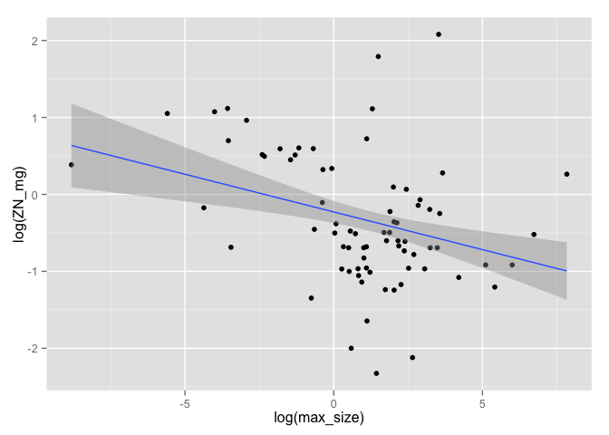

```r
library(visreg)
ntbl %>%
  filter(!is.na(Abs_lat)) %>%
  filter(!is.na(ZN_mg)) %>%
  filter(!is.na(taxon)) %>%
  filter(!is.na(TL)) %>%
  filter(!is.na(Habitat)) %>%
  filter(!is.na(max_size)) %>%
  ggplot(., aes(x=log(max_size), y=log(ZN_mg))) + stat_summary(fun.y= "mean", geom = "point") + geom_smooth(method = 'lm')
```

```r
ntbl.ZN <- ntbl %>%
  filter(!is.na(Abs_lat)) %>%
  filter(!is.na(ZN_mg)) %>%
  filter(!is.na(taxon)) %>%
  filter(!is.na(TL)) %>%
  filter(!is.na(Habitat)) %>%
  filter(!is.na(max_size))

ZN.1 <- lm(log(ZN_mg) ~ log(max_size)*TL + log(max_size)*Abs_lat + log(max_size)*Habitat, data=ntbl.ZN, na.action = "na.fail")

dredge(ZN.1) #' best model set includes latitude, size, and TL
```

```
## Fixed term is "(Intercept)"
```

```
## Global model call: lm(formula = log(ZN_mg) ~ log(max_size) * TL + log(max_size) *
##     Abs_lat + log(max_size) * Habitat, data = ntbl.ZN, na.action = "na.fail")
## ---
## Model selection table
##        (Int)  Abs_lat Hbt log(max_siz)       TL Abs_lat:log(max_siz)
## 6    0.84570 -0.02737         -0.05814
## 14   0.97720 -0.02709         -0.05377 -0.04188
## 22   0.84730 -0.02735         -0.05149                    -1.777e-04
## 8    0.06446 -0.02708   +     -0.06235
## 2    0.87300 -0.02973
## 40   0.03356 -0.02864   +     -0.08746
## 78   1.07700 -0.02705         -0.13000 -0.07639
## 10   1.23600 -0.02845                  -0.11750
## 30   0.97530 -0.02709         -0.05090 -0.04106           -7.896e-05
## 16   0.18720 -0.02692   +     -0.05827 -0.03814
```

[output cut: 62 more lines]

```r
ZN.R1 <- lm(log(ZN_mg) ~ Abs_lat + log(max_size), data=ntbl.ZN, na.action = "na.fail")

ZN.R2 <- lm(log(ZN_mg) ~ Abs_lat + log(max_size) + TL, data=ntbl.ZN, na.action = "na.fail")

ZN.avg <- model.avg(ZN.R1, ZN.R2)

summary(ZN.avg)
```

```
##
## Call:
## model.avg.default(object = ZN.R1, ZN.R2)
##
## Component model call:
## lm(formula = <2 unique values>, data = ntbl.ZN, na.action =
##      na.fail)
##
## Component models:
##     df  logLik   AICc delta weight
## 12   4 -170.35 348.96  0.00   0.73
## 123  5 -170.25 350.90  1.94   0.27
##
## Term codes:
##       Abs_lat log(max_size)            TL
##             1             2             3
##
## Model-averaged coefficients:
## (full average)
##                Estimate Std. Error Adjusted SE z value Pr(>|z|)
## (Intercept)    0.881844   0.242011    0.243823   3.617 0.000298 ***
## Abs_lat       -0.027294   0.004087    0.004120   6.625  < 2e-16 ***
## log(max_size) -0.056937   0.025010    0.025207   2.259 0.023898 *
## TL            -0.011499   0.054170    0.054551   0.211 0.833046
##
## (conditional average)
##                Estimate Std. Error Adjusted SE z value Pr(>|z|)
## (Intercept)    0.881844   0.242011    0.243823   3.617 0.000298 ***
## Abs_lat       -0.027294   0.004087    0.004120   6.625  < 2e-16 ***
## log(max_size) -0.056937   0.025010    0.025207   2.259 0.023898 *
## TL            -0.041881   0.097031    0.097805   0.428 0.668498
## ---
## Signif. codes:  0 '***' 0.001 '**' 0.01 '*' 0.05 '.' 0.1 ' ' 1
##
## Relative variable importance:
##                      Abs_lat log(max_size) TL
## Importance:          1.00    1.00          0.27
## N containing models:    2       2             1
```

```r
ZN.size <- lm(log(ZN_mg) ~ log(max_size), data=ntbl.ZN)
summary(ZN.1)
```

```
##
## Call:
## lm(formula = log(ZN_mg) ~ log(max_size) * TL + log(max_size) *
##     Abs_lat + log(max_size) * Habitat, data = ntbl.ZN, na.action = "na.fail")
##
## Residuals:
##     Min      1Q  Median      3Q     Max
## -2.5238 -0.3381 -0.0940  0.3604  1.7107
##
## Coefficients: (1 not defined because of singularities)
##                                  Estimate Std. Error t value Pr(>|t|)
## (Intercept)                      0.236777   0.835323   0.283    0.777
## log(max_size)                   -0.189963   0.164406  -1.155    0.250
## TL                              -0.074063   0.121310  -0.611    0.542
## Abs_lat                         -0.028970   0.004575  -6.332 2.74e-09 ***
## Habitatfreshwater                0.854533   0.744765   1.147    0.253
## Habitatmarine                    0.950729   0.754953   1.259    0.210
## log(max_size):TL                 0.016889   0.041274   0.409    0.683
## log(max_size):Abs_lat            0.001204   0.001800   0.669    0.505
## log(max_size):Habitatfreshwater  0.075806   0.060771   1.247    0.214
## log(max_size):Habitatmarine            NA         NA      NA       NA
## ---
## Signif. codes:  0 '***' 0.001 '**' 0.01 '*' 0.05 '.' 0.1 ' ' 1
##
## Residual standard error: 0.7294 on 148 degrees of freedom
## Multiple R-squared:  0.3041, Adjusted R-squared:  0.2665
## F-statistic: 8.084 on 8 and 148 DF,  p-value: 5.037e-09
```

This function allows me to average the top models and then prints out a table with the relevant AIC values, and importance weights. One thing I would like it to be able to do, but haven’t yet figured out, is to select the top model set and then average them, all in one function. Right now I need to do the model selection process outside the function and plop in the top models into the function. It’d be great if I could automate that process somehow!

```r
AIC.table <- function(mod1, mod2) {
  model.average <-  model.avg(mod1, mod2)
  return((msTable <- model.average$msTable))
  }
```